# Bellabeat Data Analysis Case Study

Jacob Copeland

2023-08-03

## Introduction

Welcome to my Bellabeat data analysis case study! In this project, I have assumed the role of a junior data analyst at Bellabeat, a high-tech manufacturer of health-focused products for women. I will be followig the data analysis process to answer key business questions and provide next steps for the Bellabeat to become a larger player in the global smart device market.

Bellabeat Products:

- Bellabeat App: Used to help track user data on activity, sleep, stress, menstral cycle, and mindfulness habits. All smart devices connect with the app to provide a central location for users.
- Leaf: Wellness tracker that can be worn as braclet, necklace, or clip. Used to track user activity, sleep, and stress.
- Time: Wellness watch to help track user activity, sleep, and stress.
- Spring: Smart water bottle used to track user’s daily hydration levels.
- Bellabeat Membership: Subscribtion-based membership that offers users 24/7 access to personalized guides on nutrition, activity, sleep, health and beauty, and mindfulness.

## Scenario

I have been asked to focus on one product and provide an analysis on that smart device’s data to see how consumers are using said product. I will also be presenting my findings to the Bellabeat executive team as well as a recommendation for the company’s marketing team to help find new growth opportunities.

### Deliverables

I will be using the data analysis process to produce the following deliverables:

1. A clear summary of the business task
2. A description of all data sources used
3. Documentation of any cleaning or manipulation of data
4. A summary of your analysis
5. Supporting visualizations and key findings
6. Your top high-level content recommendations based on your analysis

## Step 1: Ask

Bellabeat cofounder and Cheif Creative Officer, Urška Sršen, has tasked me with analyzing smart device data on consumers using non-Bellabeat devices and apply this insight in my presentation to answer the following questions:

1. What are some trends in smart device usage?
2. How could these trends apply to Bellabeat customers?
3. How could these trends help influence Bellabeat marketing strategy?

### Deliverable for Step 1

In this phase, I have identified my key stakeholders: the marketing and excecutive team for Bellabeat As well as the business task: Analyzing non-Bellabeat smart device data to help strengthen marketing stratagies on one Bellabeat product to aid the company in becoming a larger player in the global market.

After considering all of the available products, I chose to work with Leaf. I think the idea of a different style of a wearable smart device is very unique!

## Step 2: Prepare

I was pointed towards [this](https://www.kaggle.com/datasets/arashnic/fitbit) data set from Kaggle. It contains personal fitness tracker data from about thirty FitBit users who consented to submitting their personal data including minute-level output for physical activity, heart rate, and sleep monitoring as well as daily activity, steps, and heart rate.

I know that for my chosen product, I will need data that deals with how active the users are, their stress levels (I will be assuming this as heart rate), and what their sleep patterns are like.

### Importing the data

The first thing I need to do after downloading the data set is importing it into R. To do this I need to:

- Install and upload required packages

```r
library(janitor)
library(skimr)
library(tidyverse)
```

```r
library(dplyr)
library(ggplot2)
```

- Set me current working directory where the data set is being stored.

```r
setwd("~/R/BellaBeat")
```

- Next, I need to import the spreadsheets I will be using

```r
daily_activity <- read_csv("Fitabase Data 4.12.16-5.12.16/dailyActivity_merged.csv")
heartrate <- read_csv("Fitabase Data 4.12.16-5.12.16/heartrate_seconds_merged.csv")
sleep <- read_csv("Fitabase Data 4.12.16-5.12.16/sleepDay_merged.csv")
```

### Inspecting the Data

Now that I have all the spreadsheets needed for my analysis, it’s time to prepare these data sets for for the next step!

I’ll start by getting a small sample of each set to get an idea of the structure and values of each column as well as check for any outliers in the numeric columns.

```r
summary(daily_activity)
```

```
##        Id            ActivityDate         TotalSteps    TotalDistance
##  Min.   :1.504e+09   Length:940         Min.   :    0   Min.   : 0.000
##  1st Qu.:2.320e+09   Class :character   1st Qu.: 3790   1st Qu.: 2.620
##  Median :4.445e+09   Mode  :character   Median : 7406   Median : 5.245
##  Mean   :4.855e+09                      Mean   : 7638   Mean   : 5.490
##  3rd Qu.:6.962e+09                      3rd Qu.:10727   3rd Qu.: 7.713
##  Max.   :8.878e+09                      Max.   :36019   Max.   :28.030
##  TrackerDistance  LoggedActivitiesDistance VeryActiveDistance
##  Min.   : 0.000   Min.   :0.0000           Min.   : 0.000
##  1st Qu.: 2.620   1st Qu.:0.0000           1st Qu.: 0.000
##  Median : 5.245   Median :0.0000           Median : 0.210
##  Mean   : 5.475   Mean   :0.1082           Mean   : 1.503
##  3rd Qu.: 7.710   3rd Qu.:0.0000           3rd Qu.: 2.053
##  Max.   :28.030   Max.   :4.9421           Max.   :21.920
##  ModeratelyActiveDistance LightActiveDistance SedentaryActiveDistance
##  Min.   :0.0000           Min.   : 0.000      Min.   :0.000000
##  1st Qu.:0.0000           1st Qu.: 1.945      1st Qu.:0.000000
##  Median :0.2400           Median : 3.365      Median :0.000000
##  Mean   :0.5675           Mean   : 3.341      Mean   :0.001606
##  3rd Qu.:0.8000           3rd Qu.: 4.782      3rd Qu.:0.000000
##  Max.   :6.4800           Max.   :10.710      Max.   :0.110000
##  VeryActiveMinutes FairlyActiveMinutes LightlyActiveMinutes SedentaryMinutes
##  Min.   :  0.00    Min.   :  0.00      Min.   :  0.0        Min.   :   0.0
##  1st Qu.:  0.00    1st Qu.:  0.00      1st Qu.:127.0        1st Qu.: 729.8
##  Median :  4.00    Median :  6.00      Median :199.0        Median :1057.5
##  Mean   : 21.16    Mean   : 13.56      Mean   :192.8        Mean   : 991.2
##  3rd Qu.: 32.00    3rd Qu.: 19.00      3rd Qu.:264.0        3rd Qu.:1229.5
##  Max.   :210.00    Max.   :143.00      Max.   :518.0        Max.   :1440.0
##     Calories
##  Min.   :   0
##  1st Qu.:1828
##  Median :2134
##  Mean   :2304
##  3rd Qu.:2793
##  Max.   :4900
```

```r
head(daily_activity)
```

```
## # A tibble: 6 × 15
##           Id ActivityDate TotalSteps TotalDistance TrackerDistance
##        <dbl> <chr>             <dbl>         <dbl>           <dbl>
## 1 1503960366 4/12/2016         13162          8.5             8.5
## 2 1503960366 4/13/2016         10735          6.97            6.97
## 3 1503960366 4/14/2016         10460          6.74            6.74
## 4 1503960366 4/15/2016          9762          6.28            6.28
## 5 1503960366 4/16/2016         12669          8.16            8.16
## 6 1503960366 4/17/2016          9705          6.48            6.48
## # ℹ 10 more variables: LoggedActivitiesDistance <dbl>,
## #   VeryActiveDistance <dbl>, ModeratelyActiveDistance <dbl>,
## #   LightActiveDistance <dbl>, SedentaryActiveDistance <dbl>,
## #   VeryActiveMinutes <dbl>, FairlyActiveMinutes <dbl>,
## #   LightlyActiveMinutes <dbl>, SedentaryMinutes <dbl>, Calories <dbl>
```

```r
summary(heartrate)
```

```
##        Id                Time               Value
##  Min.   :2.022e+09   Length:2483658     Min.   : 36.00
##  1st Qu.:4.388e+09   Class :character   1st Qu.: 63.00
##  Median :5.554e+09   Mode  :character   Median : 73.00
##  Mean   :5.514e+09                      Mean   : 77.33
##  3rd Qu.:6.962e+09                      3rd Qu.: 88.00
##  Max.   :8.878e+09                      Max.   :203.00
```

```r
head(heartrate)
```

```
## # A tibble: 6 × 3
##           Id Time                 Value
##        <dbl> <chr>                <dbl>
## 1 2022484408 4/12/2016 7:21:00 AM    97
## 2 2022484408 4/12/2016 7:21:05 AM   102
## 3 2022484408 4/12/2016 7:21:10 AM   105
## 4 2022484408 4/12/2016 7:21:20 AM   103
## 5 2022484408 4/12/2016 7:21:25 AM   101
## 6 2022484408 4/12/2016 7:22:05 AM    95
```

```r
summary(sleep)
```

```
##        Id              SleepDay         TotalSleepRecords TotalMinutesAsleep
##  Min.   :1.504e+09   Length:413         Min.   :1.000     Min.   : 58.0
##  1st Qu.:3.977e+09   Class :character   1st Qu.:1.000     1st Qu.:361.0
##  Median :4.703e+09   Mode  :character   Median :1.000     Median :433.0
##  Mean   :5.001e+09                      Mean   :1.119     Mean   :419.5
##  3rd Qu.:6.962e+09                      3rd Qu.:1.000     3rd Qu.:490.0
##  Max.   :8.792e+09                      Max.   :3.000     Max.   :796.0
##  TotalTimeInBed
##  Min.   : 61.0
##  1st Qu.:403.0
##  Median :463.0
##  Mean   :458.6
##  3rd Qu.:526.0
##  Max.   :961.0
```

```r
head(sleep)
```

```
## # A tibble: 6 × 5
##           Id SleepDay        TotalSleepRecords TotalMinutesAsleep TotalTimeInBed
##        <dbl> <chr>                       <dbl>              <dbl>          <dbl>
## 1 1503960366 4/12/2016 12:0…                 1                327            346
## 2 1503960366 4/13/2016 12:0…                 2                384            407
## 3 1503960366 4/15/2016 12:0…                 1                412            442
## 4 1503960366 4/16/2016 12:0…                 2                340            367
## 5 1503960366 4/17/2016 12:0…                 1                700            712
## 6 1503960366 4/19/2016 12:0…                 1                304            320
```

Finally, I’ll double check everything to make absolutely sure I haven’t missed anything.

```r
skim(daily_activity)
```

Data summary

| Name | daily_activity |
| --- | --- |
| Number of rows | 940 |
| Number of columns | 15 |
| _______________________ |  |
| Column type frequency: |  |
| character | 1 |
| numeric | 14 |
| ________________________ |  |
| Group variables | None |

**Variable type: character**

| skim_variable | n_missing | complete_rate | min | max | empty | n_unique | whitespace |
| --- | --- | --- | --- | --- | --- | --- | --- |
| ActivityDate | 0 | 1 | 8 | 9 | 0 | 31 | 0 |

**Variable type: numeric**

| skim_variable | n_missing | complete_rate | mean | sd | p0 | p25 | p50 | p75 | p100 | hist |
| --- | --- | --- | --- | --- | --- | --- | --- | --- | --- | --- |
| Id | 0 | 1 | 4.855407e+09 | 2.424805e+09 | 1503960366 | 2.320127e+09 | 4.445115e+09 | 6.962181e+09 | 8.877689e+09 | ▇▅▃▅▅ |
| TotalSteps | 0 | 1 | 7.637910e+03 | 5.087150e+03 | 0 | 3.789750e+03 | 7.405500e+03 | 1.072700e+04 | 3.601900e+04 | ▇▇▁▁▁ |
| TotalDistance | 0 | 1 | 5.490000e+00 | 3.920000e+00 | 0 | 2.620000e+00 | 5.240000e+00 | 7.710000e+00 | 2.803000e+01 | ▇▆▁▁▁ |
| TrackerDistance | 0 | 1 | 5.480000e+00 | 3.910000e+00 | 0 | 2.620000e+00 | 5.240000e+00 | 7.710000e+00 | 2.803000e+01 | ▇▆▁▁▁ |
| LoggedActivitiesDistance | 0 | 1 | 1.100000e-01 | 6.200000e-01 | 0 | 0.000000e+00 | 0.000000e+00 | 0.000000e+00 | 4.940000e+00 | ▇▁▁▁▁ |
| VeryActiveDistance | 0 | 1 | 1.500000e+00 | 2.660000e+00 | 0 | 0.000000e+00 | 2.100000e-01 | 2.050000e+00 | 2.192000e+01 | ▇▁▁▁▁ |
| ModeratelyActiveDistance | 0 | 1 | 5.700000e-01 | 8.800000e-01 | 0 | 0.000000e+00 | 2.400000e-01 | 8.000000e-01 | 6.480000e+00 | ▇▁▁▁▁ |
| LightActiveDistance | 0 | 1 | 3.340000e+00 | 2.040000e+00 | 0 | 1.950000e+00 | 3.360000e+00 | 4.780000e+00 | 1.071000e+01 | ▆▇▆▁▁ |
| SedentaryActiveDistance | 0 | 1 | 0.000000e+00 | 1.000000e-02 | 0 | 0.000000e+00 | 0.000000e+00 | 0.000000e+00 | 1.100000e-01 | ▇▁▁▁▁ |
| VeryActiveMinutes | 0 | 1 | 2.116000e+01 | 3.284000e+01 | 0 | 0.000000e+00 | 4.000000e+00 | 3.200000e+01 | 2.100000e+02 | ▇▁▁▁▁ |
| FairlyActiveMinutes | 0 | 1 | 1.356000e+01 | 1.999000e+01 | 0 | 0.000000e+00 | 6.000000e+00 | 1.900000e+01 | 1.430000e+02 | ▇▁▁▁▁ |
| LightlyActiveMinutes | 0 | 1 | 1.928100e+02 | 1.091700e+02 | 0 | 1.270000e+02 | 1.990000e+02 | 2.640000e+02 | 5.180000e+02 | ▅▇▇▃▁ |
| SedentaryMinutes | 0 | 1 | 9.912100e+02 | 3.012700e+02 | 0 | 7.297500e+02 | 1.057500e+03 | 1.229500e+03 | 1.440000e+03 | ▁▁▇▅▇ |
| Calories | 0 | 1 | 2.303610e+03 | 7.181700e+02 | 0 | 1.828500e+03 | 2.134000e+03 | 2.793250e+03 | 4.900000e+03 | ▁▆▇▃▁ |

```r
skim(heartrate)
```

Data summary

| Name | heartrate |
| --- | --- |
| Number of rows | 2483658 |
| Number of columns | 3 |
| _______________________ |  |
| Column type frequency: |  |
| character | 1 |
| numeric | 2 |
| ________________________ |  |
| Group variables | None |

**Variable type: character**

| skim_variable | n_missing | complete_rate | min | max | empty | n_unique | whitespace |
| --- | --- | --- | --- | --- | --- | --- | --- |
| Time | 0 | 1 | 19 | 21 | 0 | 961274 | 0 |

**Variable type: numeric**

| skim_variable | n_missing | complete_rate | mean | sd | p0 | p25 | p50 | p75 | p100 | hist |
| --- | --- | --- | --- | --- | --- | --- | --- | --- | --- | --- |
| Id | 0 | 1 | 5.513765e+09 | 1950223761.0 | 2022484408 | 4388161847 | 5553957443 | 6962181067 | 8877689391 | ▃▇▇▅▃ |
| Value | 0 | 1 | 7.733000e+01 | 19.4 | 36 | 63 | 73 | 88 | 203 | ▇▇▁▁▁ |

```r
skim(sleep)
```

Data summary

| Name | sleep |
| --- | --- |
| Number of rows | 413 |
| Number of columns | 5 |
| _______________________ |  |
| Column type frequency: |  |
| character | 1 |
| numeric | 4 |
| ________________________ |  |
| Group variables | None |

**Variable type: character**

| skim_variable | n_missing | complete_rate | min | max | empty | n_unique | whitespace |
| --- | --- | --- | --- | --- | --- | --- | --- |
| SleepDay | 0 | 1 | 20 | 21 | 0 | 31 | 0 |

**Variable type: numeric**

| skim_variable | n_missing | complete_rate | mean | sd | p0 | p25 | p50 | p75 | p100 | hist |
| --- | --- | --- | --- | --- | --- | --- | --- | --- | --- | --- |
| Id | 0 | 1 | 5.000979e+09 | 2.06036e+09 | 1503960366 | 3977333714 | 4702921684 | 6962181067 | 8792009665 | ▆▆▇▅▃ |
| TotalSleepRecords | 0 | 1 | 1.120000e+00 | 3.50000e-01 | 1 | 1 | 1 | 1 | 3 | ▇▁▁▁▁ |
| TotalMinutesAsleep | 0 | 1 | 4.194700e+02 | 1.18340e+02 | 58 | 361 | 433 | 490 | 796 | ▁▂▇▃▁ |
| TotalTimeInBed | 0 | 1 | 4.586400e+02 | 1.27100e+02 | 61 | 403 | 463 | 526 | 961 | ▁▃▇▁▁ |

### Deliverable for Step 2

- **Daily activity**
  - Steps
    - Total daily steps
    - Total distance
  - Activity level
    - Very active (distance and minutes)
    - Moderately active (distance and minutes)
    - Lightly active (distance and minutes)
  - Calories
- **Heart Rate**
  - Recorded every 5 seconds
  - The heart rate at the time of recording
- **Sleep**
  - Minutes asleep
  - Minutes spent in bed

Afterwards, I looked at a preview of the data sets to get a better idea of what the data is telling me and where I need to start the cleaning process.

## Step 3: Process

Now that I have a better understanding of what this data is telling me, it’s time to clean it up a little so I can accurately analyze it.

I’ll start with any missing values. After getting a summary of all the spreadsheets, I noticed that none of the spreadsheets I am using have missing values, but its always a good idea to double check!

```r
summary(is.na(daily_activity))
```

```
##      Id          ActivityDate    TotalSteps      TotalDistance
##  Mode :logical   Mode :logical   Mode :logical   Mode :logical
##  FALSE:940       FALSE:940       FALSE:940       FALSE:940
##  TrackerDistance LoggedActivitiesDistance VeryActiveDistance
##  Mode :logical   Mode :logical            Mode :logical
##  FALSE:940       FALSE:940                FALSE:940
##  ModeratelyActiveDistance LightActiveDistance SedentaryActiveDistance
##  Mode :logical            Mode :logical       Mode :logical
##  FALSE:940                FALSE:940           FALSE:940
##  VeryActiveMinutes FairlyActiveMinutes LightlyActiveMinutes SedentaryMinutes
##  Mode :logical     Mode :logical       Mode :logical        Mode :logical
##  FALSE:940         FALSE:940           FALSE:940            FALSE:940
##   Calories
##  Mode :logical
##  FALSE:940
```

```r
summary(is.na(heartrate))
```

```
##      Id             Time           Value
##  Mode :logical   Mode :logical   Mode :logical
##  FALSE:2483658   FALSE:2483658   FALSE:2483658
```

```r
summary(is.na(sleep))
```

```
##      Id           SleepDay       TotalSleepRecords TotalMinutesAsleep
##  Mode :logical   Mode :logical   Mode :logical     Mode :logical
##  FALSE:413       FALSE:413       FALSE:413         FALSE:413
##  TotalTimeInBed
##  Mode :logical
##  FALSE:413
```

Now that I have taken care of all NA values, I will move on to any duplicates.

```r
sum(duplicated(daily_activity))
```

```
## [1] 0
```

```r
sum(duplicated(heartrate))
```

```
## [1] 0
```

```r
sum(duplicated(sleep))
```

```
## [1] 3
```

So there is only one spreadsheet with duplicates I will need to remove!

```r
duplicates <- sleep[duplicated(sleep) | duplicated(sleep, fromLast = TRUE), ]
View(duplicates)
sleep_no_dupe <- sleep[!duplicated(sleep), ]
```

The next step in the process phase is to clean up the column names for readability.

```r
daily_activity_clean <- clean_names(daily_activity)
```

```r
heartrate_clean <- clean_names(heartrate)
```

```r
sleep_clean <- clean_names(sleep_no_dupe)
```

This will help ensure that all of the column names are uniform.

I want to do is add a new column in the spreadsheets so that I will also have the day of the week as well as the date.

```r
sleep_clean$sleep_day <- as.Date(sleep_clean$sleep_day, format = "%m/%d/%Y")
sleep_clean$day_of_week <- wday(sleep_clean$sleep_day, label = TRUE)
glimpse(sleep_clean)
```

```
## Rows: 410
## Columns: 6
## $ id                   <dbl> 1503960366, 1503960366, 1503960366, 1503960366, 1…
## $ sleep_day            <date> 2016-04-12, 2016-04-13, 2016-04-15, 2016-04-16, …
## $ total_sleep_records  <dbl> 1, 2, 1, 2, 1, 1, 1, 1, 1, 1, 1, 1, 1, 1, 1, 1, 1…
## $ total_minutes_asleep <dbl> 327, 384, 412, 340, 700, 304, 360, 325, 361, 430,…
## $ total_time_in_bed    <dbl> 346, 407, 442, 367, 712, 320, 377, 364, 384, 449,…
## $ day_of_week          <ord> Tue, Wed, Fri, Sat, Sun, Tue, Wed, Thu, Sat, Sun,…
```

```r
daily_activity_clean$activity_date <- as.Date(daily_activity_clean$activity_date, format = "%m/%d/%Y")
daily_activity_clean$day_of_week <- wday(daily_activity_clean$activity_date, label = TRUE)
glimpse(daily_activity_clean)
```

```
## Rows: 940
## Columns: 16
## $ id                         <dbl> 1503960366, 1503960366, 1503960366, 1503960…
## $ activity_date              <date> 2016-04-12, 2016-04-13, 2016-04-14, 2016-0…
## $ total_steps                <dbl> 13162, 10735, 10460, 9762, 12669, 9705, 130…
## $ total_distance             <dbl> 8.50, 6.97, 6.74, 6.28, 8.16, 6.48, 8.59, 9…
## $ tracker_distance           <dbl> 8.50, 6.97, 6.74, 6.28, 8.16, 6.48, 8.59, 9…
## $ logged_activities_distance <dbl> 0, 0, 0, 0, 0, 0, 0, 0, 0, 0, 0, 0, 0, 0, 0…
## $ very_active_distance       <dbl> 1.88, 1.57, 2.44, 2.14, 2.71, 3.19, 3.25, 3…
## $ moderately_active_distance <dbl> 0.55, 0.69, 0.40, 1.26, 0.41, 0.78, 0.64, 1…
## $ light_active_distance      <dbl> 6.06, 4.71, 3.91, 2.83, 5.04, 2.51, 4.71, 5…
## $ sedentary_active_distance  <dbl> 0, 0, 0, 0, 0, 0, 0, 0, 0, 0, 0, 0, 0, 0, 0…
## $ very_active_minutes        <dbl> 25, 21, 30, 29, 36, 38, 42, 50, 28, 19, 66,…
## $ fairly_active_minutes      <dbl> 13, 19, 11, 34, 10, 20, 16, 31, 12, 8, 27, …
## $ lightly_active_minutes     <dbl> 328, 217, 181, 209, 221, 164, 233, 264, 205…
## $ sedentary_minutes          <dbl> 728, 776, 1218, 726, 773, 539, 1149, 775, 8…
## $ calories                   <dbl> 1985, 1797, 1776, 1745, 1863, 1728, 1921, 2…
## $ day_of_week                <ord> Tue, Wed, Thu, Fri, Sat, Sun, Mon, Tue, Wed…
```

I also want to separate the date and time from the heart rate spreadsheet

```r
heartrate_clean <- separate(heartrate_clean, time, into = c("date", "time_in_seconds"), sep = " ")
heartrate_clean$date <- as.Date(heartrate_clean$date, format = "%m/%d/%Y")
heartrate_clean$day_of_week <- wday(heartrate_clean$date, label = TRUE)
glimpse(heartrate_clean)
```

```
## Rows: 2,483,658
## Columns: 5
## $ id              <dbl> 2022484408, 2022484408, 2022484408, 2022484408, 202248…
## $ date            <date> 2016-04-12, 2016-04-12, 2016-04-12, 2016-04-12, 2016-…
## $ time_in_seconds <chr> "7:21:00", "7:21:05", "7:21:10", "7:21:20", "7:21:25",…
## $ value           <dbl> 97, 102, 105, 103, 101, 95, 91, 93, 94, 93, 92, 89, 83…
## $ day_of_week     <ord> Tue, Tue, Tue, Tue, Tue, Tue, Tue, Tue, Tue, Tue, Tue,…
```

And create a new column for total minutes in daily activity

```r
daily_activity_clean <- daily_activity_clean %>%
  mutate(total_minutes = very_active_minutes + fairly_active_minutes + lightly_active_minutes + sedentary_minutes)
```

Finally, I want to see the total hours asleep and hours in bed.

```r
sleep_clean <- sleep_clean %>%
  mutate(total_hours_asleep = total_minutes_asleep / 60)
sleep_clean <- sleep_clean %>%
  mutate(total_hours_in_bed = total_time_in_bed / 60)
```

Now I can perform analysis on how active the users were on each day of the week and the sleeping trends per day!

### Deliverable for Step 3

Now that my data is clean, it’s time to start my analysis and make some predictions!

To start, I need to see all the trends in the following:

- Average distance by day

```r
avg_distance_by_day <- daily_activity_clean %>%
  select(day_of_week, total_distance) %>%
  group_by(day_of_week) %>%
  summarize(total_distance = mean(total_distance, na.rm = TRUE))
View(avg_distance_by_day)
```

- Average steps by day

```r
avg_steps_by_day <- daily_activity_clean %>%
  select(day_of_week, total_steps) %>%
  group_by(day_of_week) %>%
  summarize(total_steps = mean(total_steps, na.rm = TRUE))
View(avg_steps_by_day)
```

```r
avg_active_minutes_by_day <- daily_activity_clean %>%
  select(day_of_week, total_minutes) %>%
  group_by(day_of_week) %>%
  summarize(total_minutes = mean(total_minutes, na.rm = TRUE))
View(avg_active_minutes_by_day)
```

- Sleep patterns

```r
avg_hours_asleep <- sleep_clean %>%
  group_by(day_of_week) %>%
  summarize(
    average_hours_asleep = mean(total_hours_asleep, na.rm = TRUE)
  ) %>%
  mutate(
    average_hours_asleep = round(average_hours_asleep, 2)
  ) %>%
  select(day_of_week, average_hours_asleep)
View(avg_hours_asleep)
```

- Total active minutes per day

```r
active_per_day <- daily_activity_clean %>%
  select(day_of_week, very_active_minutes, fairly_active_minutes,
         lightly_active_minutes, sedentary_minutes) %>%
  group_by(day_of_week) %>%
  summarise(
    total_very_active = sum(very_active_minutes, na.rm = TRUE),
    total_fairly_active = sum(fairly_active_minutes, na.rm = TRUE),
    total_lightly_active = sum(lightly_active_minutes, na.rm = TRUE),
    total_sedentary = sum(sedentary_minutes, na.rm = TRUE)
  )
View(active_per_day)
```

## Step 5: Share

Now its time for my favorite part of the data analytics process: Data visualizations!

To start, I will create several graphs to illustrate my analysis.

My first graph will be on the average distance tracked by day.

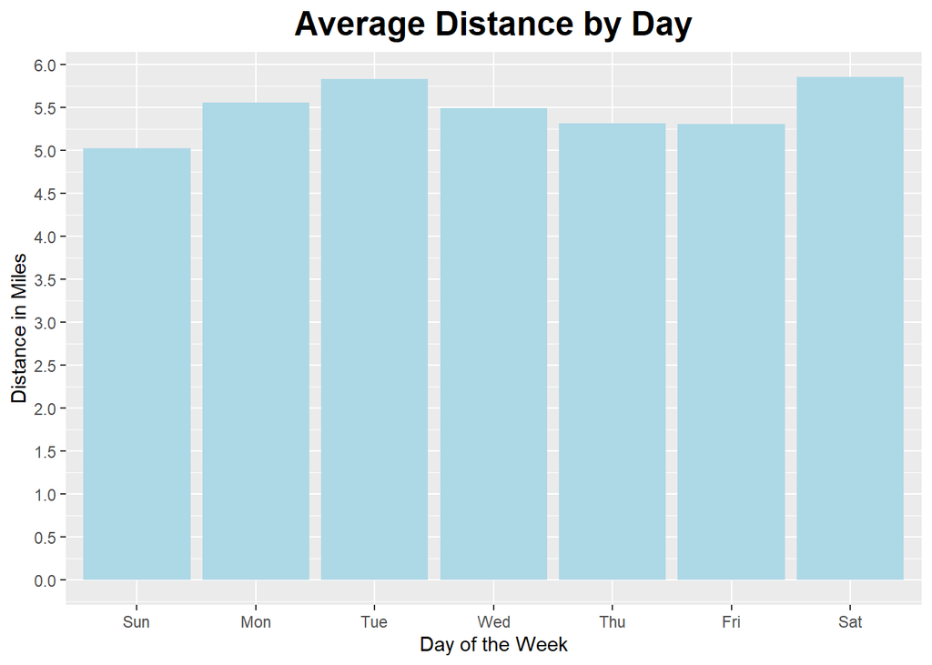

```r
ggplot(avg_distance_by_day, aes(x = day_of_week, y = total_distance)) +
  geom_bar(stat = "identity", fill = "lightblue") +
  scale_y_continuous(breaks = seq(0, 6, by = 0.5)) +
  labs(title = "Average Distance by Day", x = "Day of the Week", y = "Distance in Miles") +
  theme(plot.title = element_text(size = 18, face = "bold", hjust = 0.5))
```

Next is the average steps

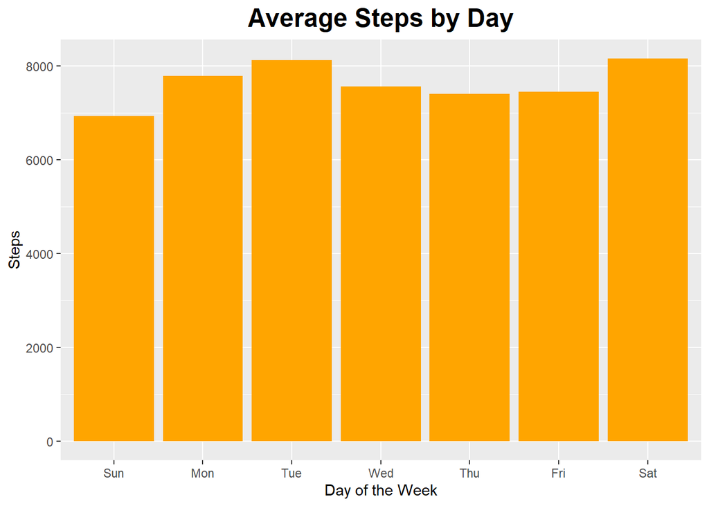

```r
ggplot(avg_steps_by_day, aes(x = day_of_week, y = total_steps)) +
  geom_bar(stat = "identity", fill = "orange") +
  labs(title = "Average Steps by Day", x = "Day of the Week", y = "Steps") +
  theme(plot.title = element_text(size = 18, face = "bold", hjust = 0.5))
```

Now I’ll do the average hours asleep

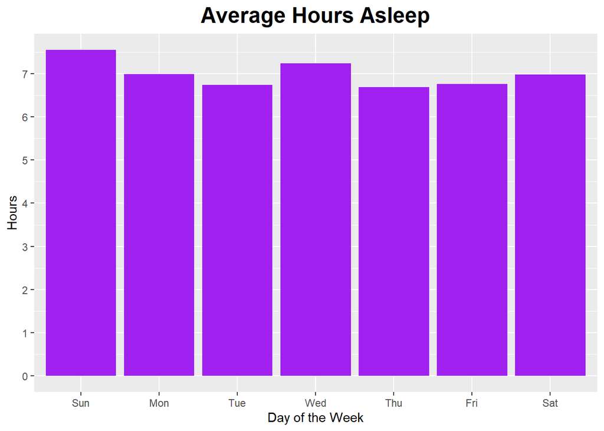

```r
ggplot(avg_hours_asleep, aes(x = day_of_week, y = average_hours_asleep)) +
  geom_bar(stat = "identity", fill = "purple") +
  scale_y_continuous(breaks = seq(0, 8)) +
  labs(title = "Average Hours Asleep", x = "Day of the Week", y = "Hours") +
  theme(plot.title = element_text(size = 18, face = "bold", hjust = 0.5))
```

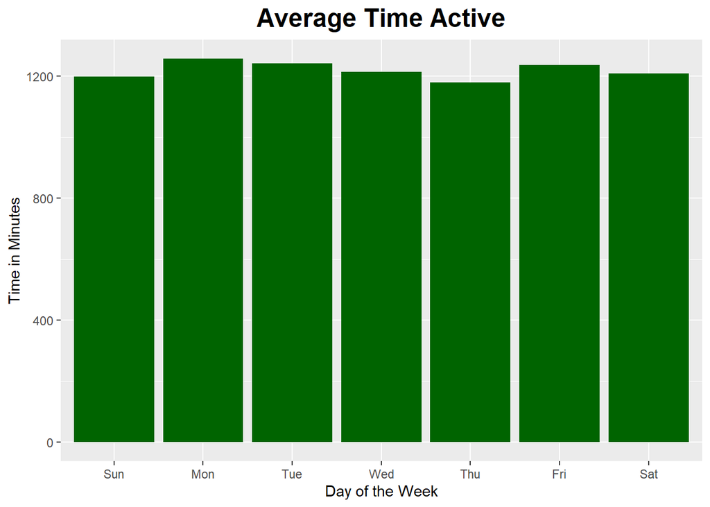

```r
ggplot(avg_active_minutes_by_day, aes(x = day_of_week, y = total_minutes)) +
  geom_bar(stat = "identity", fill = "darkgreen") +
  labs(title = "Average Time Active", x = "Day of the Week", y = "Time in Minutes") +
  theme(plot.title = element_text(size = 18, face = "bold", hjust = 0.5))
```

## Step 6: Act

Based on this analysis, I believe that the subscription would be the most marketable product in addition to the Leaf. The wearable device is unique because almost every wearable smart device for fitness is a watch and to be able to have a product that can be a necklace, clip, or bracelet could add more personality than a standard watch. However, since the data does not provide information such as age, health conditions, or gender, it is more difficult to provide a truly accurate recommendation. Because of this, I believe the subscription would also be beneficial as it can provide a customized wellness plan for each consumer.